# Introdução a Análise de Dados em R

# **Banco de Dados**

## 1. **Diretório de Trabalho**

O R trabalha com uma pasta especifica em seu computador, importando e salvando arquivos nesta pasta, chamada de *diretório de trabalho* (*Working Directory*). A Função getwd() informa qual o diretório atual em que se está trabalhando:

```r
getwd()
```

Crie uma pasta de trabalho para os estudos em R em seu computador e use a Função setwd() para defini-la como seu diretório de trabalho. Clique com o botão direito do seu mouse nesta pasta, selecione propriedades, copie o caminho computacional daquela pasta, cole no lugar do exemplo entre aspas (certifique-se de que as barras estão viradas para o lado direito). Por fim, Função list.files() lista todos os arquivos presentes no seu diretório.

```r
setwd("INSIRA/SEU/CAMINHO/AQUI/Estudos em R")

list.files()
```

## 2. **Importar Bases**

Para ler um arquivo, algo importante ao saber o formato que ele se encontra. Esse formato deve preencher alguns pré-requisitos das funões de leitura. A tabela abaixo lista as funões para importar os tipos mais comuns segundo a extensÃ£o do arquivo e o pacote necessário.

| **Formato do Arquivo** | **Função** | **Pacote** |
| --- | --- | --- |
| .csv | read.csv() | base |
| .xls e .xlsx (Excel) | read_excel() | readxl |
| .sav (SPSS) | read_sav() | haven |
| .dat (STATA) | read_stata() | haven |
| .sas7bdat (SAS) | read_sas() | haven |

## 3. *Exercício*

1. Entre no portal [Dados Abertos Recife](http://dados.recife.pe.gov.br/dataset/acidentes-de-transito-com-e-sem-vitimas) e baixe a base da CTTU para os acidentes de trânsito em Recife, no ano 2016;
2. Mova o banco para sua pasta de trabalho;
3. Carregue o banco no R.

# **Manipulação de Dados**

## 1. **Visualizar Bancos de Dados**

Para visualizar as informações contidas em uma base de dados podemos usar uma série de ferramentas no R. Dentre elas:

```r
str(acidentes_transito_2016)   # Nos retorna a estrutura do banco, com informacoes sobre o banco em si e suas variaveis
View(acidentes_transito_2016)  # Abre uma janela no RStudio na qual é possível visualizar uma planilha da base

head(acidentes_transito_2016)  # Visualizar primeira linhas do banco
tail(acidentes_transito_2016)  # Visualizar ultimas linhas do banco
```

## 2. **Manipular Estrutura do Banco**

```r
# selecionar primeira coluna no banco
acidentes_transito_2016[,1]

# selecionar primeira linha no banco
acidentes_transito_2016[1,]

# remover primeira coluna no banco e atribuir a novo objeto
acidentes_transito_2016.2 <- acidentes_transito_2016[,-1]

# remover 10 primeiras linha no banco
acidentes_transito_2016.2 <- acidentes_transito_2016.2[-c(1:10),]

# visualizar banco acidentes_transito_2016.2
head(acidentes_transito_2016.2)
```

```r
# selecionar coluna "situacao" no banco
situacao <- acidentes_transito_2016[,c("situacao")]

# visualizar situacao
situacao

# retirar primeiros 10 casos de situacao e atribuir a situacao2
situacao2 <- situacao[-c(1:10)]

# visualizar situacao2
situacao2
```

## 2.**Manipulando Dados com Condicionais**

As vezes você quer ir além de simplesmente selecionar uma coluna ou linha especifica. Você pode querer selecionar apenas os casos de acidentes em que houve vítima, os que envolveram ciclistas ou ainda os que envolveram moto ou caminhão e deixaram vítima. Para tal podemos trabalhar com operações lógicas utilizando as informações que aprendemos até agora.

```r
# as.factor() transforma um vector em factor (vetor com informacao categorica)
acidentes_transito_2016$tipo <- as.factor(acidentes_transito_2016$tipo)

# ver categorias na variavel
levels(acidentes_transito_2016$tipo)
```

```
[1] ""                "APOIO"           "COM VÍTIMA"      "ENTRADA E SAÍDA"
[5] "FISCALIZAÇÃO"    "MONITORAMENTO"   "SEM VÍTIMA"      "VÍTIMA FATAL"
```

```r
# Selecionar acidentes de transito com vitimas
acid_transit_vitima2016 <- acidentes_transito_2016[acidentes_transito_2016$tipo == "COM VÍTIMA",]

# transformar variavel em numerica
acidentes_transito_2016$ciclista <- as.numeric(acidentes_transito_2016$ciclista)

# Selecionar acidentes de transito envolvendo ciclista
acid_transit_ciclista2016 <- acidentes_transito_2016[acidentes_transito_2016$ciclista == 1,]

# retirar casos faltantes (NAs) no banco
acid_transit_ciclista2016 <- acid_transit_ciclista2016[complete.cases(acid_transit_ciclista2016),]
```

# **Introdução à Visualização de Dados**

Apresentar dados de uma maneira informativa e de fácil compreensão é uma tarefa que está no cotidiano de cada analista de dados. O *R* é uma ótima ferramenta para produção de mapas, gráficos e tabelas, com diversos pacotes para isso. Escolheu-se o uso do pacote [ggplot2](http://ggplot2.tidyverse.org/reference/), por este ser o pacote com mais material de aprendizado e solução de dúvidas nos forúns de R e também pelos layout dos gráficos que podem ser produzidos.

Para instalar o pacote ggplot no seu computador execute a seguinte função no R:

```r
# instala o pacote e suas dependencias
install.packages("gpglot2", dependencies = T)

# apos instalado devemos carrega-lo
library(ggplot2)
```

## Qual o número de acidentes envolvendo ciclistas em cada bairro do Recife?

Na base de dados da CTTU temos as ocorrências de acidentes. No banco ‘acid_transit_ciclista2016’ estão as ocorrênicas de acidentes envolvendo ciclistas. Para responder à pergunta acima nós poderíamos ir contando o bairro de cada um dos 170 acidentes envolvendo ciclistas em 2016, mas no R nós podemos fazer isso de forma automática:

```r
# table() conta o numero de vezes que um determinado valor aparece em uma variavel
table(acid_transit_ciclista2016$bairro)
```

```
            AFOGADOS            ÁGUA FRIA ALTO SANTA TERESINHA
                   5                    5                    1
              AREIAS               ARRUDA     BAIRRO DO RECIFE
                   5                    3                    1
            BEBERIBE           BOA VIAGEM            BOA VISTA
                   3                   12                    5
  BOMBA DO HEMETÉRIO              CABANGA             CAJUEIRO
                   1                    1                    1
        CAMPO GRANDE         CASA AMARELA           CASA FORTE
                   4                    5                    6
             CAXANGÁ              COELHOS             CORDEIRO
                   5                    2                   11
               DERBY         ENCRUZILHADA             ESTÂNCIA
                   5                    4                    2
              GRAÇAS            HIPÓDROMO                IBURA
                   2                    1                    3
       ILHA DO LEITE   ILHA JOANA BEZERRA          IMBIRIBEIRA
                   1                    1                   10
               IPSEP             IPUTINGA             JAQUEIRA
                   3                    3                    1
    JARDIM SÃO PAULO        JOANA BEZERRA            MACAXEIRA
                   1                    1                    3
            MADALENA            MANGUEIRA            PAISSANDU
                   4                    1                    3
                PINA                PRADO            ROSARINHO
                   7                    2                    2
          SAN MARTIN          SANTO AMARO        SANTO ANTÔNIO
                   4                    8                    3
            SÃO JOSÉ          TAMARINEIRA              TEJIPIÓ
                   4                    2                    1
               TORRE              TORREÃO              TORRÕES
                   2                    1                    5
              VÁRZEA        VASCO DA GAMA
                   2                    2
```

```r
# podemos fazer um dataframe com essa informacao e armezena-lo
bairro_acid_ciclista <- data.frame(table(acid_transit_ciclista2016$bairro))

# ordenar o banco de dados com base nos acidentes
bairro_acid_ciclista <- bairro_acid_ciclista[order(bairro_acid_ciclista$Freq, decreasing = TRUE),]

# Selecionar apenas os 15 primeiros bairros com maior numero de acidentes
bairro_acid_ciclista2 <- bairro_acid_ciclista[1:15, ]

# visualizar banco manipulado
bairro_acid_ciclista2
```

```
           Var1 Freq
8    BOA VIAGEM   12
18     CORDEIRO   11
27  IMBIRIBEIRA   10
41  SANTO AMARO    8
37         PINA    7
15   CASA FORTE    6
1      AFOGADOS    5
2     ÁGUA FRIA    5
4        AREIAS    5
9     BOA VISTA    5
14 CASA AMARELA    5
16      CAXANGÁ    5
19        DERBY    5
48      TORRÕES    5
13 CAMPO GRANDE    4
```

```r
# salvar banco de dados manipulado
write.csv(bairro_acid_ciclista2, file = "bairros_+15_acidentes_ciclistas.csv")
```

### Nosso primeiro gráfico!!

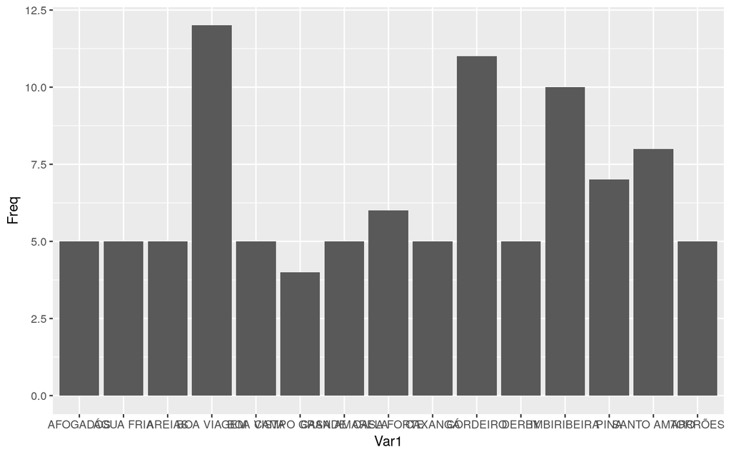

```r
ggplot(data = bairro_acid_ciclista2,  # selecionar o banco de dados
       aes(x = Var1, y = Freq) ) +    # selecionar variaveis do eixo x e y
       geom_col()                     # selecionar tipo de gráfico a ser plotado
```

### Editando o gráfico

Podemos melhorar nosso gráfico editando algumas coisas simples nele:

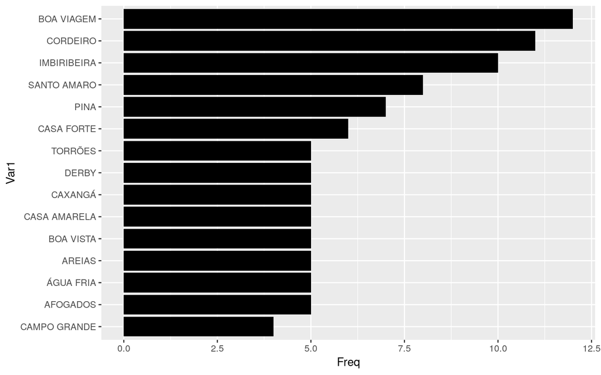

```r
# tranformar nomes em fatores ordenados
bairro_acid_ciclista2$Var1 <- factor(bairro_acid_ciclista2$Var1, bairro_acid_ciclista2$Var1[order(bairro_acid_ciclista2$Freq)])

# grafico ggplot
ggplot(data = bairro_acid_ciclista2,  aes(x = Var1, y = Freq ) ) +
       geom_col(fill = "black") +  # definir cor de preenchimento das barras
       coord_flip()                # inverter eixos do grafico
```

# **Manipulação de Dados**

Nesta aula vamos avançar um pouco mais na manipulação e visualização de dados e também executar alguns cálculos de estatística descritiva. O primeiro banco de dados que iremos trabalhar é o [AtlasBrasil](https://github.com/claudioalvesmonteiro/aulas_analisededados/blob/master/Dados/AtlasBrasil_Consulta.csv). Entre no repositório e selecione *Raw*, depois clique com o botão direito do mouse na página, selecione *salvar como* e salve o banco na sua pasta de trabalho.

Com base no que você já aprendeu, importe o banco de dados no R a partir da linha de comando.

**Atenção!** Lembre-se de que uma das maiores funcionalidades do R é a replicabilidade das análises. Assim, devemos deixar os códigos salvos em um script que siga uma execução eficiente.

#### Exercício

Depois de carregar o banco, visualize-o e tente identificar um erro nos casos da tabela. Após identificado, corrija-o com base no que você já aprendeu nas aulas anteriores.

### Pacote *stringr*

Outro problema no banco é na variável “IDHM”, que está com a decimal demilitada por “,” em vez de “.” (padrão de decimal usado no R). Se pedirmos para o R nos retornar a classe desta variável podemos ver que ela é da classe *character*. Para trabalharmos com ela vamos substituir a “,” pelo “.” e para tal utilizaremos o pacote *stringr*.

```r
# classe da variavel IDHM
class(atlas_brasil$IDHM.2010)
```

```
[1] "character"
```

```r
# instalar e carregar pacote stringr
install.packages("stringr", dependencies = T)
library(stringr)
```

```r
# vamos primeiro olhar a documentacao da funcao 'str_replace'
?str_replace

# substituir "," por "."
atlas_brasil$IDHM.2010 <- str_replace(atlas_brasil$IDHM.2010, ",", ".")

# classe da variavel
class(atlas_brasil$IDHM.2010)
```

```
[1] "character"
```

#### Exercício

Ao pedir a classe da variável é possível observar que ela ainda permanece como *character*. Transforme-a em numérica com base no que você já aprendeu.

Outra funcionalidade interessante do pacote *stringr* é que podemos detectar casos em uma variável que possuem um padrão específico de letras. Podemos observar na variavel “Espacialidades” que a sigla do estado de cada munícipio está na mesma coluna que o nome do mesmo:

```r
head(atlas_brasil$Espacialidades, 20)
```

```
 [1] "Brasil"                   "Abadia de Goiás (GO)"
 [3] "Abadia dos Dourados (MG)" "Abadiânia (GO)"
 [5] "Abaeté (MG)"              "Abaetetuba (PA)"
 [7] "Abaiara (CE)"             "Abaíra (BA)"
 [9] "Abaré (BA)"               "Abatiá (PR)"
[11] "Abdon Batista (SC)"       "Abelardo Luz (SC)"
[13] "Abel Figueiredo (PA)"     "Abre Campo (MG)"
[15] "Abreu E Lima (PE)"        "Abreulândia (TO)"
[17] "Acaiaca (MG)"             "Açailândia (MA)"
[19] "Acajutiba (BA)"           "Acará (PA)"
```

Para exemplificiar, podemos criar uma variável no banco que nos informará se a cidade é do Estado de Pernambuco com base na funcao *str_detect*:

```r
# detectar o padrao "PE" na variavel "Espacialidades" e atribuir o resultado a uma nova variavel
atlas_brasil$pernambuco <- str_detect(atlas_brasil$Espacialidades, "(PE)")

# agora podemos criar uma nova base de dados apenas com os casos de PE
atlas_pe <- atlas_brasil[atlas_brasil$pernambuco == TRUE,]
```

# **Estatísticas Descritivas**

Agora iremos baixar outra base de dados, o banco “2018 EPI Country Snapshot” disponível no projeto [Enviromental Performance Index](https://epi.envirocenter.yale.edu/epi-downloads). Entre no repositório, baixe o banco de dados e salve-o na sua pasta de trabalho e importe-o para o R. Iremos usar este banco para executar algumas estatísticas descritivas:

```r
library(readr)
EPIdata <- read_csv("dados/epi2018countrysnapshotv01.csv")
```

```r
# calcular media
mean(EPIdata$EPI2018Score)
```

```
[1] 56.40889
```

```r
# mediana
median(EPIdata$EPI2018Score)
```

```
[1] 56.405
```

```r
# desvio-padrao
sd(EPIdata$EPI2018Score)
```

```
[1] 12.85758
```

```r
# valor minimo e maximo
min(EPIdata$EPI2018Score)
```

```
[1] 27.43
```

```r
max(EPIdata$EPI2018Score)
```

```
[1] 87.42
```

```r
# funcao summary
summary(EPIdata$EPI2018Score)
```

```
   Min. 1st Qu.  Median    Mean 3rd Qu.    Max.
  27.43   46.25   56.41   56.41   64.73   87.42
```

### Selecionando casos máximos e mínimos

Com base no que aprendemos sobre manipulação de banco de dados é possível deduzir como construir um código que crie um banco de dados com os casos de valor máximo de uma variável e outro com os valores mínimos. Tente desenvolver com base na variável “EPI2018Score”.

# **Gráficos Descritivos**

### Histograma e densidade

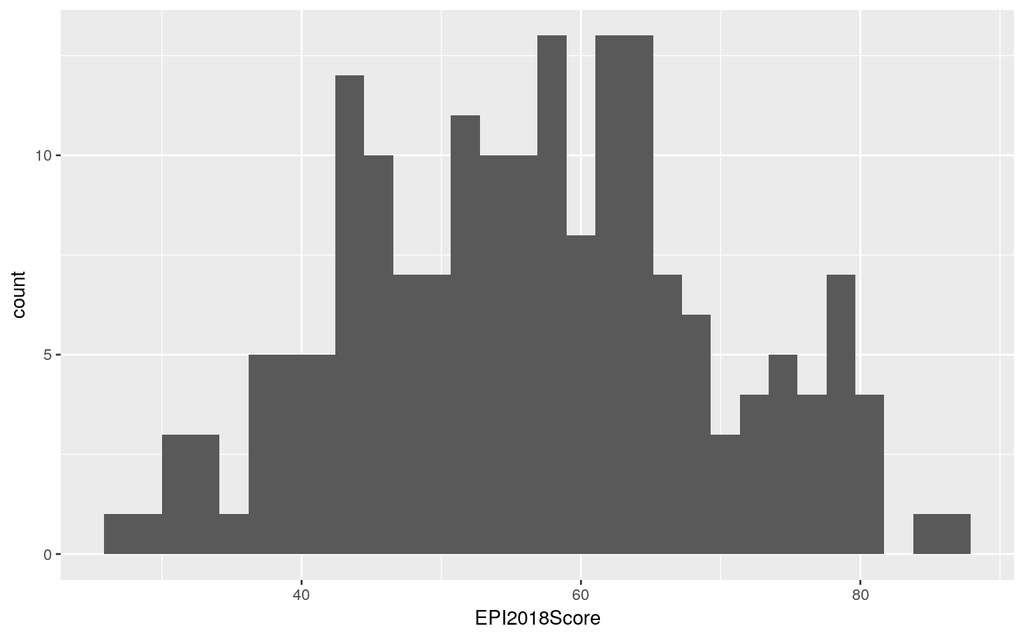

```r
# carregue o pacote ggplot2
library(ggplot2)

# executar histograma IDHM para Pernambuco
ggplot(data = EPIdata, aes(x = EPI2018Score))+
  geom_histogram()
```

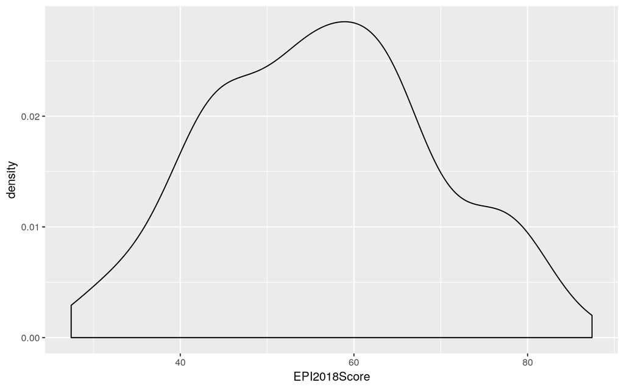

```r
# executar densidade IDHM para Pernambuco
ggplot(data = EPIdata, aes(x = EPI2018Score))+
  geom_density()
```

### Boxplot

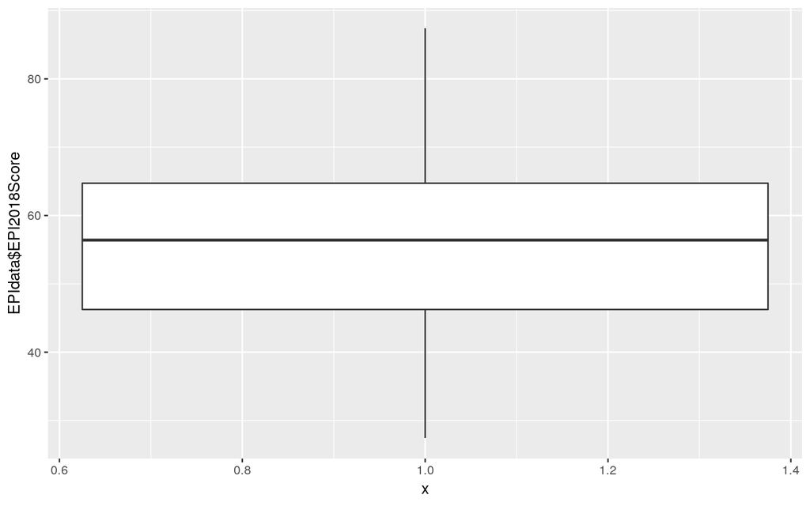

```r
# executar boxplot
ggplot(EPIdata)+
  geom_boxplot(aes(y = EPIdata$EPI2018Score, x = 1))
```

#### Exercício

Uma das principais questões envolvendo o aprendizado do R é a capacidade de encontrar resoluções para procedimentos no R na internet, pois o R detém uma série de comunidades, blogs e forúns online, o que facilita esse processo. Para exemplificar isso faça o seguinte: (1) procure na internet como alterar o título dos eixos X e Y num gráfico *ggplot*; e (2) procure como alterar a cor de fundo do gráfico.

```r
## ALTERE OS TITULOS DOS EIXOS X E Y NO GRAFICO ABAIXO, NO SEU SCRIPT
ggplot(data = EPIdata, aes(x = EPI2018Score))+
  geom_histogram()

## ALTERE A COR DE FUNDO NO GRAFICO ABAIXO, NO SEU SCRIPT
ggplot(data = EPIdata, aes(x = EPI2018Score))+
  geom_histogram()
```

[^1]: Os argumentos de uma função são as informaões que ela necessita para ser executada, algumas funões tomam certos argumentos como padrão e outros é necessário que seja informado algo. Por exemplo, a Função plot() necessita do argumento x (dados no eixo das abscissas) e y (dados no eixo das ordenadas) para ser executada.

Analytique Consultoria

Janeiro, 2019